# Can Norwegians afford a house in Oslo?

Salary estimates for individuals with completed higher education (level 7-8) with any field of study.

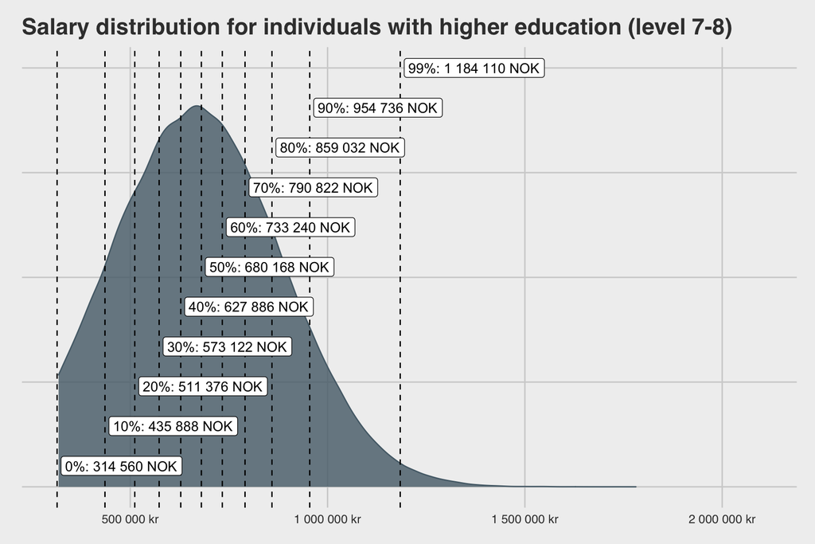

```
## Selected areas: Majorstu[en, a], Frogner, Fagerborg, Bislett, Marienlyst, Sagene, Bjølsen, Nydalen, Tåsen, Grünnerløkka, St. Hanshaugen, Holmen, Torshov, Kjelsås, Sogn, Storo
```

```
## 92.77% of university graduates can afford the cheapest house in selected areas
```

[output not shown]

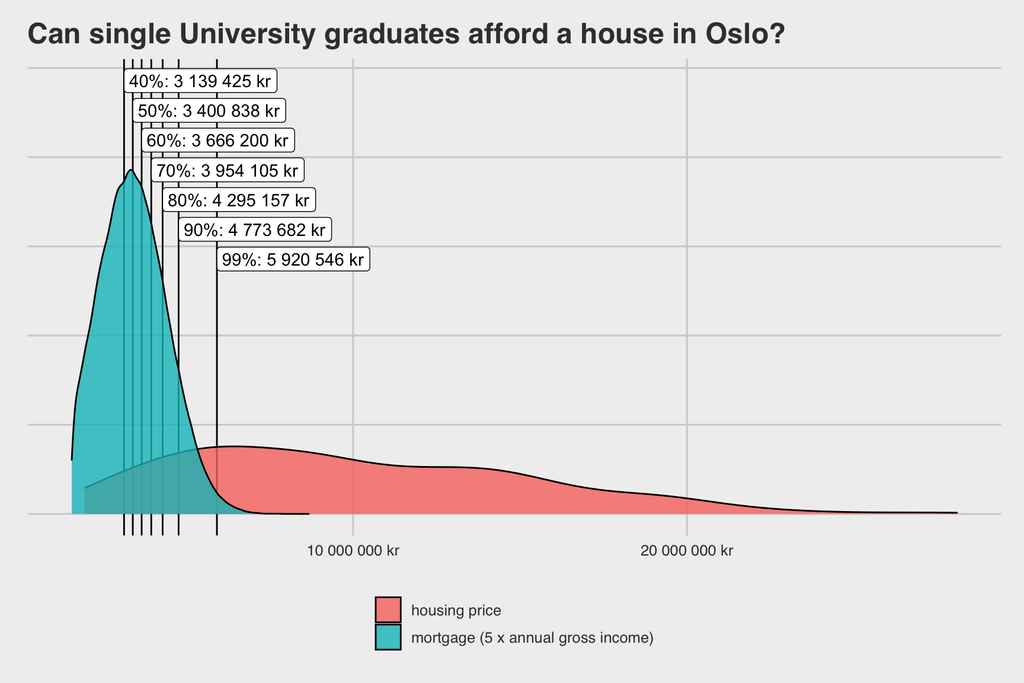

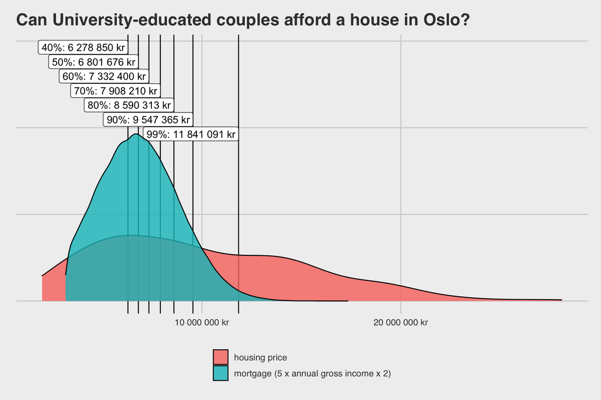

# Relevant scenarios for NORMENT employees

## SCENARIO 1: University-educated couple with 2 children

Show listings that an university-educated couple with the 40th percentile salary can afford (60% has higher income and potential mortgage), that has space to give each child their own bedroom. Maximum mortgage defined as 5 times the gross annual income with no previous loans. No ground floor apparments to allow work from home,

| id | location | address | price | soverom | bruksareal | etasje | price_per_m2 | date_changed | ad_url |
| --- | --- | --- | --- | --- | --- | --- | --- | --- | --- |
| 215258177 | Vestre Holmen/Røa | Pilotveien 10, 0770 Oslo | 5.150.000 | 3 | 76m2 | 5 | 67.763,16 | 2021-04-28 | https://www.finn.no/realestate/homes/ad.html?finnkode=215258177 |
| 215936716 | St. Hanshaugen | Waldemar Thranes gate 62C, 0173 Oslo | 5.990.000 | 3 | 85m2 | 4 | 70.470,59 | 2021-04-25 | https://www.finn.no/realestate/homes/ad.html?finnkode=215936716 |
| 207436422 | Majorstuen | Kirkeveien 48A, 0368 Oslo | 5.990.000 | 3 | 78m2 | 2 | 76.794,87 | 2021-04-22 | https://www.finn.no/realestate/homes/ad.html?finnkode=207436422 |
| 215184645 | Ila/Sagene | Uelands gate 61A, 0460 Oslo | 6.000.000 | 3 | 96m2 | 3 | 62.500,00 | 2021-04-20 | https://www.finn.no/realestate/homes/ad.html?finnkode=215184645 |

# SCENARIO 2: Single university graduate

Show listings that an university-educated individual with salary in the 40th percentile can afford. Fegardless of years since completion of higher education. Additional requirements are at least one bedroom, and not on the ground floor to allow work from home with little disturbance. Maximum mortgage defined as 5 times the gross annual income with no previous loans.

| id | location | address | price | soverom | bruksareal | etasje | price_per_m2 | date_changed | ad_url |
| --- | --- | --- | --- | --- | --- | --- | --- | --- | --- |
| 215718904 | St. Hanshaugen / Alexander Kiellands Pl. | Uelands gate 24A, 0175 Oslo | 1.950.000 | 1 | 27m2 | 6 | 72.222,22 | 2021-04-28 | https://www.finn.no/realestate/homes/ad.html?finnkode=215718904 |
| 214295557 | Nydalen/Storo | Gunnar Schjelderups vei 33C, 0485 Oslo | 2.000.000 | 1 | 31m2 | 2 | 64.516,13 | 2021-04-11 | https://www.finn.no/realestate/homes/ad.html?finnkode=214295557 |
| 216561701 | Majorstuen | Sporveisgata 35A, 0354 Oslo | 2.250.000 | 1 | 13m2 | 2 | 173.076,92 | 2021-04-27 | https://www.finn.no/realestate/homes/ad.html?finnkode=216561701 |
| 216579567 | Majorstuen/Nye Major | Sørkedalsveien 9B, 0367 Oslo | 2.800.000 | 1 | 41m2 | 6 | 68.292,68 | 2021-04-27 | https://www.finn.no/realestate/homes/ad.html?finnkode=216579567 |
| 215993418 | Perfekt Førstegangskjøp På Bjølsen | Maridalsveien 205, 0469 Oslo | 3.100.000 | 1 | 37m2 | 2 | 83.783,78 | 2021-04-26 | https://www.finn.no/realestate/homes/ad.html?finnkode=215993418 |

## SCENARIO 3: young university graduate

Show salary and mortage distributions for a single young university graduate. Young in this case is defined as 0-4 years post-graduation in Natural sciences, vocational and technical subjects.

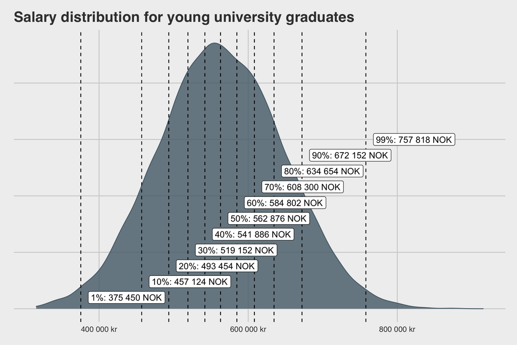

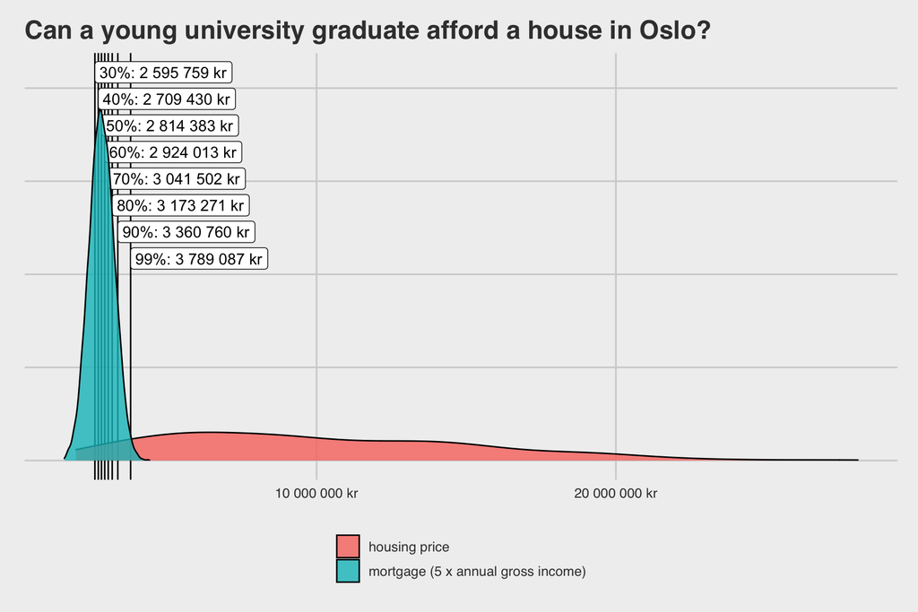

## Listings young university graduates in the 40th percentile can afford

| id | location | address | price | soverom | bruksareal | etasje | price_per_m2 | date_changed | ad_url |
| --- | --- | --- | --- | --- | --- | --- | --- | --- | --- |
| 215718904 | St. Hanshaugen / Alexander Kiellands Pl. | Uelands gate 24A, 0175 Oslo | 1.950.000 | 1 | 27m2 | 6 | 72.222,22 | 2021-04-28 | https://www.finn.no/realestate/homes/ad.html?finnkode=215718904 |
| 214295557 | Nydalen/Storo | Gunnar Schjelderups vei 33C, 0485 Oslo | 2.000.000 | 1 | 31m2 | 2 | 64.516,13 | 2021-04-11 | https://www.finn.no/realestate/homes/ad.html?finnkode=214295557 |
| 216561701 | Majorstuen | Sporveisgata 35A, 0354 Oslo | 2.250.000 | 1 | 13m2 | 2 | 173.076,92 | 2021-04-27 | https://www.finn.no/realestate/homes/ad.html?finnkode=216561701 |

### What can you get to get for less than 2 million NOK?

| id | location | address | price | soverom | bruksareal | etasje | price_per_m2 | date_changed | ad_url |
| --- | --- | --- | --- | --- | --- | --- | --- | --- | --- |
| 210899732 | Nydalen | Gunnar Schjelderups vei 33B, 0485 Oslo | 1.900.000 | 1 | 39m2 | 1 | 48.717,95 | 2021-04-25 | https://www.finn.no/realestate/homes/ad.html?finnkode=210899732 |
| 213057141 | Bislett | Thereses gate 35B, 0354 Oslo | 1.900.000 | 0 | 15m2 | 3 | 126.666,67 | 2021-04-19 | https://www.finn.no/realestate/homes/ad.html?finnkode=213057141 |
| 215718904 | St. Hanshaugen / Alexander Kiellands Pl. | Uelands gate 24A, 0175 Oslo | 1.950.000 | 1 | 27m2 | 6 | 72.222,22 | 2021-04-28 | https://www.finn.no/realestate/homes/ad.html?finnkode=215718904 |
| 214295557 | Nydalen/Storo | Gunnar Schjelderups vei 33C, 0485 Oslo | 2.000.000 | 1 | 31m2 | 2 | 64.516,13 | 2021-04-11 | https://www.finn.no/realestate/homes/ad.html?finnkode=214295557 |